# Reproducible Research: Assignment 1

## Loading and preprocessing the data

```r
originalData <- read.csv("activity.csv")
```

First 5 rows of original data:

```
##   steps       date interval
## 1    NA 2012-10-01        0
## 2    NA 2012-10-01        5
## 3    NA 2012-10-01       10
## 4    NA 2012-10-01       15
## 5    NA 2012-10-01       20
```

## What is mean total number of steps taken per day?

Creating dataset containing the total number of steps taken each day

```r
dailyStepSum <- aggregate(originalData$steps, list(originalData$date), sum)
```

First 5 rows of daily Step Sum data:

```
##         Date Steps
## 1 2012-10-01    NA
## 2 2012-10-02   126
## 3 2012-10-03 11352
## 4 2012-10-04 12116
## 5 2012-10-05 13294
```

2. Creating histogram of daily Step Data

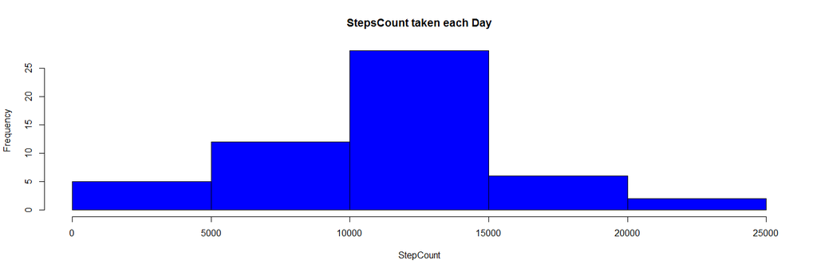

```r
 hist(dailyStepSum$Steps,col="blue",xlab="StepCount",ylab="Frequency",main="StepsCount taken each Day")
```

3. Calculating the mean and median values (ignoring NA values) using the daily step count dataset.
4. Mean

```r
dailyStepMean <- mean(dailyStepSum$Steps, na.rm=TRUE)
```

```
## [1] 10766.19
```

2. Median

```r
dailyStepMedian <- median(dailyStepSum$Steps, na.rm=TRUE)
```

```
## [1] 10765
```

## What is the average daily activity pattern?

Finding the mean (average) steps taken for eatch 5-minute time interval averaged over all the days in the data-

1. Generating the mean (average) number of steps taken (ignoring NA values) for each 5-minute interval, itself averaged across all days.

```r
intervalSteps <- aggregate(
        data=originalData,
        steps~interval,
        FUN=mean,
        na.action=na.omit
)
colnames(intervalSteps) <- c("Interval", "AvgStepsAvgAcrossDay")
```

First 5 rows in new dataset:

````
    ```
    ##   Interval AvgStepsAvgAcrossDay
    ## 1        0            1.7169811
    ## 2        5            0.3396226
    ## 3       10            0.1320755
    ## 4       15            0.1509434
    ## 5       20            0.0754717
    ```
````

2. A Time-Series plot is created from the above dataset

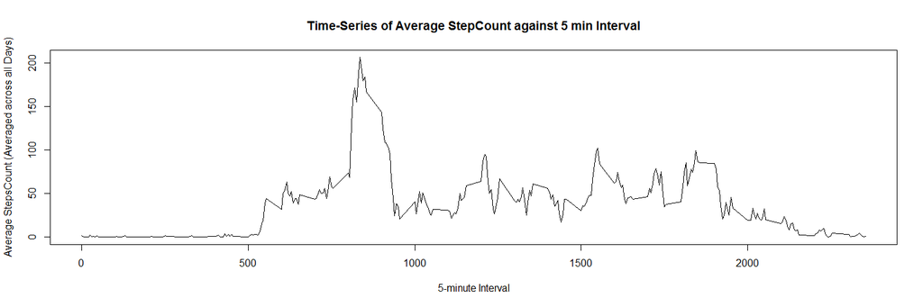

```r
with(intervalSteps, {
        plot(
                x=Interval,
                y=AvgStepsAvgAcrossDay,
                type="l",
                main="Time-Series of Average StepCount against 5 min Interval",
                xlab="5-minute Interval",
                ylab="Average StepsCount (Averaged across all Days)"

        )
})
```

3. Finding the 5-minute interval with the maximum number of steps

```r
intervalMax <- intervalSteps[intervalSteps$AvgStepsAvgAcrossDay==max(intervalSteps$AvgStepsAvgAcrossDay),]
```

```
##     Interval AvgStepsAvgAcrossDay
## 104      835             206.1698
```

Conclusion:

The interval between **835** and **840** minutes has the maximum number of steps.

## Imputing missing values

The goal of this section is to generate a new graph using the same data as from the first section but with its NA values replaced.

Let’s use mean (average) 5-minunte interval values from the previous section to replace the NA values.

1. Total number of rows with NA values in original data.

```r
countNA <- nrow(subset(originalData, is.na(originalData$steps)))
```

```
## [1] 2304
```

Rounding decimal to a whole number.

```r
stepValues <- data.frame(originalData$steps)
stepValues[is.na(stepValues),] <- ceiling(tapply(X=originalData$steps,INDEX=originalData$interval,FUN=mean,na.rm=TRUE))
newData <- cbind(stepValues, originalData[,2:3])
colnames(newData) <- c("Steps", "Date", "Interval")
```

5 rows of new dataset:

```
##   Steps       Date Interval
## 1     2 2012-10-01        0
## 2     1 2012-10-01        5
## 3     1 2012-10-01       10
## 4     1 2012-10-01       15
## 5     1 2012-10-01       20
```

3. The total number of steps taken each day is generated using this new dataset.

```r
newDailyStepSum <- aggregate(newData$Steps, list(newData$Date), sum)
```

5 rows of new dataset:

```
##         Date Steps
## 1 2012-10-01 10909
## 2 2012-10-02   126
## 3 2012-10-03 11352
## 4 2012-10-04 12116
## 5 2012-10-05 13294
```

4. A histogram of the above data is created as a form of visual representation.

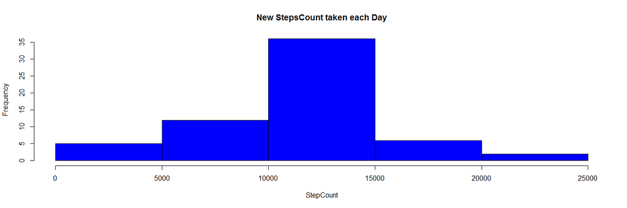

```r
 hist(newDailyStepSum$Steps,col="blue",xlab="StepCount",ylab="Frequency",main="New StepsCount taken each Day")
```

5. Calculate the mean and median values of this new dataset (NA values replaced with mean).

Mean of new dataset

```r
newDailyStepMean <- mean(newDailyStepSum$Steps)
```

```
## [1] 10784.92
```

Median of new dataset

```r
newDailyStepMedian <- median(newDailyStepSum$Steps)
```

```
## [1] 10909
```

Observation : Adding the missing values to the original data has caused both the mean and median values to increase.

1. Mean: 10766 to 10784
2. Median: 10765 to 10909

## Are there differences in activity patterns between weekdays and weekends?

A new column indicating whether the date is a weekday or a weekend is added to the new dataset created in the previous section.

```r
dateDayType <- data.frame(sapply(X=newData$Date, FUN=function(day) {
        if (weekdays(as.Date(day)) %in% c("Monday", "Tuesday", "Wednesday", "Thursday", "Friday")) {
                day <- "weekday"
        }
        else {
                day <- "weekend"
        }
}))

newDataWithDayType <- cbind(newData, dateDayType)

colnames(newDataWithDayType) <- c("Steps", "Date", "Interval", "DayType")
```

First 5 rows of new data:

```
##   Steps       Date Interval DayType
## 1     2 2012-10-01        0 weekday
## 2     1 2012-10-01        5 weekday
## 3     1 2012-10-01       10 weekday
## 4     1 2012-10-01       15 weekday
## 5     1 2012-10-01       20 weekday
```

2. The data is then separated into weekday or weekend and the mean (average) number of steps taken for each 5-minute interval, itself averaged across all weekday days or weekend days is calculated.

```r
dayTypeIntervalSteps <- aggregate(
        data=newDataWithDayType,
        Steps ~ DayType + Interval,
        FUN=mean
)
```

First 5 rows of the dataset:

```
##   DayType Interval     Steps
## 1 weekday        0 2.2888889
## 2 weekend        0 0.2500000
## 3 weekday        5 0.5333333
## 4 weekend        5 0.1250000
## 5 weekday       10 0.2888889
```

3. Finally, a panel plot of both weekend and weekday graphs is generated.

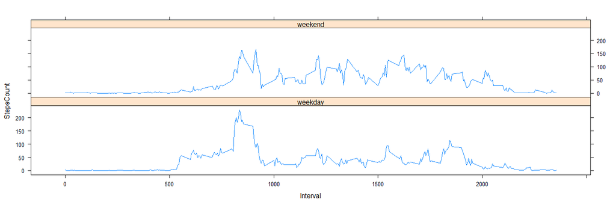

```r
library("lattice")

xyplot(
        type="l",
        data=dayTypeIntervalSteps,
        Steps ~ Interval | DayType,
        xlab="Interval",
        ylab="StepsCount",
        layout=c(1,2)
)
```